# Inferential Data Analysis

Ehab Mohamed

25 October 2015

## Data exploration

This section provides some basic exploratory data analyses and basic summary of the data.

```r
library(ggplot2)
data(ToothGrowth)
```

```r
head(ToothGrowth)
```

```
##    len supp dose
## 1  4.2   VC  0.5
## 2 11.5   VC  0.5
## 3  7.3   VC  0.5
## 4  5.8   VC  0.5
## 5  6.4   VC  0.5
## 6 10.0   VC  0.5
```

```r
dim(ToothGrowth)
```

```
## [1] 60  3
```

```r
str(ToothGrowth)
```

```
## 'data.frame':    60 obs. of  3 variables:
##  $ len : num  4.2 11.5 7.3 5.8 6.4 10 11.2 11.2 5.2 7 ...
##  $ supp: Factor w/ 2 levels "OJ","VC": 2 2 2 2 2 2 2 2 2 2 ...
##  $ dose: num  0.5 0.5 0.5 0.5 0.5 0.5 0.5 0.5 0.5 0.5 ...
```

As shown above, data has 60 observations and 3 variables:

1. len: Tooth length
2. supp: Supplement type, which is VC or OJ
3. dose: Dose in milligrams

```r
summary(ToothGrowth)
```

```
##       len        supp         dose
##  Min.   : 4.20   OJ:30   Min.   :0.500
##  1st Qu.:13.07   VC:30   1st Qu.:0.500
##  Median :19.25           Median :1.000
##  Mean   :18.81           Mean   :1.167
##  3rd Qu.:25.27           3rd Qu.:2.000
##  Max.   :33.90           Max.   :2.000
```

The below figure shows the tooth length by supplement type and dosage (mg):

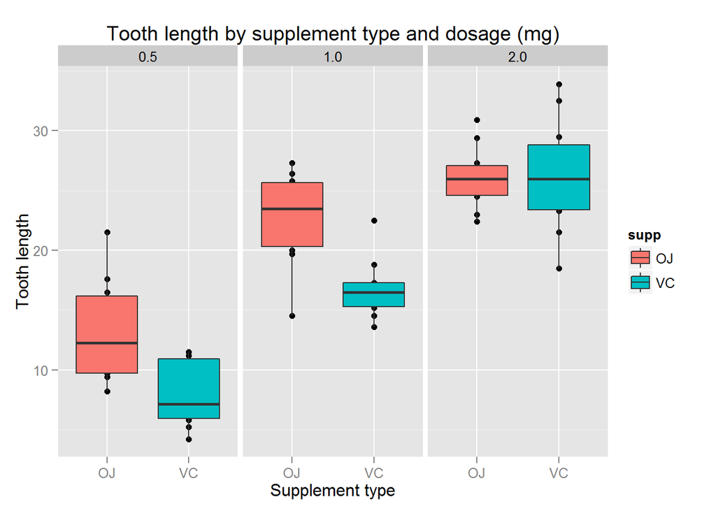

```r
qplot(supp,len,data=ToothGrowth, facets=~dose,
      main="Tooth length by supplement type and dosage (mg)",
      xlab="Supplement type", ylab="Tooth length") + geom_boxplot(aes(fill = supp))
```

As shown in the above figure, the tooth length increases as the dosage increases. However, in case of dosage 0.5 and 1.0 mg, the OJ supplement is more effective than the VC supplement.

## Hypothesis Testing

### Assumptions

- The variables must be independent and identically distributed (iid).
- Variances of tooth growth are different when using different supplement and dosage.

### Hypothesis for the supplement OJ vs VC

In this test, the null hypothesis is no difference in tooth growth when using the supplement OJ and VC.

lenOJ=lenVC

And the alternate hypothesis is more tooth growth when using supplement OJ than VC.

lenOJ>lenVC

The subsets of the data for OJ and VC supplements can be obtained as follows:

```r
OJ = ToothGrowth$len[ToothGrowth$supp == 'OJ']
VC = ToothGrowth$len[ToothGrowth$supp == 'VC']
```

Using the below t-test, the hypothesis can be examined:

```r
t.test(OJ, VC, alternative = "greater", paired = FALSE, var.equal = FALSE, conf.level = 0.95)
```

```
##
##  Welch Two Sample t-test
##
## data:  OJ and VC
## t = 1.9153, df = 55.309, p-value = 0.03032
## alternative hypothesis: true difference in means is greater than 0
## 95 percent confidence interval:
##  0.4682687       Inf
## sample estimates:
## mean of x mean of y
##  20.66333  16.96333
```

The resulting p-value is 0.03032 which is lower than 0.05 (the default value for the tolerance of the error alpha). Accordingly, the null hypothesis is rejected.

It can be comcluded that it is very likely that supplement OJ has greater effect on tooth growth than supplement VC.

### Hypothesis for the dossage

In this test, the null hypothesis is that there is no difference in tooth growth between dosage. Our alternate hypothesis is that there are more tooth growth when the dosage increases.

Subsets of different dosages can be extracted as follows:

```r
doseHalf = ToothGrowth$len[ToothGrowth$dose == 0.5]
doseOne = ToothGrowth$len[ToothGrowth$dose == 1]
doseTwo = ToothGrowth$len[ToothGrowth$dose == 2]
```

Using the below t-test, the hypothesis can be examined:

```r
t.test(doseHalf, doseOne, alternative = "less", paired = FALSE, var.equal = FALSE, conf.level = 0.95)
```

```
##
##  Welch Two Sample t-test
##
## data:  doseHalf and doseOne
## t = -6.4766, df = 37.986, p-value = 6.342e-08
## alternative hypothesis: true difference in means is less than 0
## 95 percent confidence interval:
##       -Inf -6.753323
## sample estimates:
## mean of x mean of y
##    10.605    19.735
```

As shown in the above result, the p-value, which is 6.342e-08, is lower than 0.05. Accordingly, the null hypothesis is rejected. This indicates that there is almost no chances of obtain an extreme value for the difference in mean of those dossages on the tooth growth for doseHalf < doseOne.

The below code performs the test on the One and Two dossage:

```r
t.test(doseOne, doseTwo, alternative = "less", paired = FALSE, var.equal = FALSE, conf.level = 0.95)
```

```
##
##  Welch Two Sample t-test
##
## data:  doseOne and doseTwo
## t = -4.9005, df = 37.101, p-value = 9.532e-06
## alternative hypothesis: true difference in means is less than 0
## 95 percent confidence interval:
##      -Inf -4.17387
## sample estimates:
## mean of x mean of y
##    19.735    26.100
```

The resulting p-value is 9.532e-06 which is close to 0. Accordingly, the null hypothesis is rejected. This indicates that there is almost no chances of obtain an extreme value for the difference in mean of those dossages on the tooth growth for doseOne < doseTwo.

### Hypothesis for the supplement OJ vs VC at dossage 2.0 mg

In this test, the null hypothesis is that there is no difference in tooth growth when using the supplement OJ and VC at dosage 2.0 mg.

And the alternate hypothesis is that there is difference tooth growth when using supplement OJ and VC at dosage 2.0 mg.

Subsets of different supplements can be extracted as follows:

```r
OJ2 = ToothGrowth$len[ToothGrowth$supp == 'OJ' & ToothGrowth$dose == 2]
VC2 = ToothGrowth$len[ToothGrowth$supp == 'VC' & ToothGrowth$dose == 2]
```

Using the below t-test, the hypothesis can be examined:

```r
t.test(OJ2, VC2, alternative = "two.sided", paired = FALSE, var.equal = FALSE, conf.level = 0.95)
```

```
##
##  Welch Two Sample t-test
##
## data:  OJ2 and VC2
## t = -0.046136, df = 14.04, p-value = 0.9639
## alternative hypothesis: true difference in means is not equal to 0
## 95 percent confidence interval:
##  -3.79807  3.63807
## sample estimates:
## mean of x mean of y
##     26.06     26.14
```

The resulting p-value is 0.9639 which is higher than 0.05. Accordingly, the null hypothesis can not be rejected. This indicates that there is insufficient evidence to show that there is a difference in tooth growth when using supplement OJ and VC at dosage 2.0 mg.